# Statistics in R

Basic Statistics in R

Aungkolatt

15/12/2025

```r
knitr::opts_chunk$set(echo = TRUE, message = FALSE, warning=FALSE)

# installing some r package
library(dplyr)
```

```r
library(ggplot2)
library(DescTools) # To find mode
```

# Summary Statistics

## Measures of Center

ဒေတာအစုတစ်ခုရဲ့ “အလယ်တန်ဖိုး” ကိုဖော်ပြတဲ့ အချက်အလက်များဖြစ်ပြီး၊ ဒေတာအစုရဲ့အခြေအနေကို တိုတောင်းအကျဉ်းချုပ်ဖော်ပြနိုင်ပါတယ်။

```r
data(msleep) # import the built in dataset called mammal sleep dataset


# Summary statistics
mean(msleep$sleep_total)
```

```
## [1] 10.43373
```

```r
median(msleep$sleep_total)
```

```
## [1] 10.1
```

```r
# Count and sort sleep total in descending

msleep %>% count(sleep_total, sort = TRUE)
```

```
## # A tibble: 65 × 2
##    sleep_total     n
##          <dbl> <int>
##  1        12.5     4
##  2        10.1     3
##  3         5.3     2
##  4         6.3     2
##  5         8.4     2
##  6         8.7     2
##  7         9.1     2
##  8         9.4     2
##  9         9.8     2
## 10        10.3     2
## # ℹ 55 more rows
```

```r
# Count and sort the vore total in descending

msleep %>% count(vore, sort = TRUE)
```

```
## # A tibble: 5 × 2
##   vore        n
##   <chr>   <int>
## 1 herbi      32
## 2 omni       20
## 3 carni      19
## 4 <NA>        7
## 5 insecti     5
```

```r
# Filter and summarize the vore for "Insectivores"

msleep %>%
  filter(vore == "insecti") %>%
  summarize(mean_sleep = mean(sleep_total),
            median_sleep= median(sleep_total))
```

```
## # A tibble: 1 × 2
##   mean_sleep median_sleep
##        <dbl>        <dbl>
## 1       14.9         18.1
```

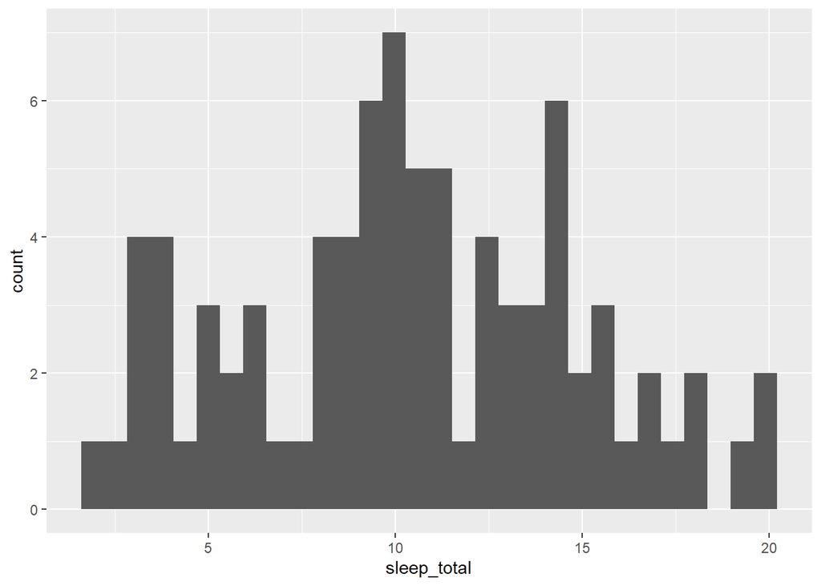

```r
# Create histogram
msleep %>%
  ggplot(aes(x=sleep_total)) +
  geom_histogram()
```

## Masure of Spread

### Standard deviation

The standard deviation is a measure of a dataset’s spread. It is calculated by taking the square root of the variance of a data set. The resulting value has the same units as the original data.

Population standard deviation:

$$\sigma = \sqrt{\frac{\sum_{i=1}^{n}(x_i - \mu)^2}{n}}$$

Sample standard deviation:

$$s = \sqrt{\frac{\sum_{i=1}^{n}(x_i - \bar{x})^2}{n - 1}}$$

### Variance

Variance is a measure of spread. It is calculated by finding the average of the squared differences between every observation and the mean. The resulting value is in units squared. A larger variance means the data is more spread out and values tend to be far away from the mean. A variance of 0 means all values in the dataset are the same.

Variance Formula:

Popoulation variance
$$\sigma^2 = \frac{\sum_{i=1}^{n} (x_i - \bar{x})^2}{n}$$

Sample Variance
$$s^2 = \frac{\sum_{i=1}^{n} (x_i - \bar{x})^2}{n - 1}$$

```r
# Computing the variance in traiditional method
dists <- msleep$sleep_total - mean(msleep$sleep_total)
dists
```

```
##  [1]  1.66626506  6.56626506  3.96626506  4.46626506 -6.43373494  3.96626506
##  [7] -1.73373494 -3.43373494 -0.33373494 -7.43373494 -5.13373494 -1.03373494
## [13] -0.43373494  2.06626506 -0.13373494 -2.13373494 -1.33373494  6.96626506
## [19] -5.13373494  7.56626506 -6.53373494  9.26626506 -7.53373494 -7.33373494
## [25] -0.33373494  0.46626506  4.46626506  2.06626506 -0.63373494 -8.53373494
## [31] -7.73373494 -4.23373494 -4.13373494 -2.43373494 -0.93373494 -7.13373494
## [37]  8.96626506 -0.33373494  3.76626506  3.86626506  2.36626506  2.06626506
## [43]  9.46626506  4.16626506  0.56626506 -2.73373494  4.06626506 -2.03373494
## [49] -6.63373494 -0.73373494  5.36626506 -0.03373494  3.06626506 -1.03373494
## [55] -0.13373494  0.56626506  1.06626506  3.26626506 -6.93373494 -4.83373494
## [61]  0.66626506  7.66626506 -5.03373494  2.56626506 -1.73373494 -0.83373494
## [67] -2.03373494  0.86626506  0.16626506  6.16626506  3.36626506  5.46626506
## [73]  2.36626506 -1.33373494 -1.83373494  5.36626506 -6.03373494  5.16626506
## [79] -1.53373494 -5.23373494 -4.13373494  2.06626506 -0.63373494
```

```r
square_dists <- (dists)^2   # square of distance
square_dists
```

```
##  [1]  2.776439251 43.115836841 15.731258528 19.947523588 41.392945275
##  [6] 15.731258528  3.005836841 11.790535637  0.111379010 55.260415155
## [11] 26.355234432  1.068607926  0.188125998  4.269451299  0.017885034
## [16]  4.552824793  1.778848890 48.528848890 26.355234432 57.248366962
## [21] 42.689692263 85.863668167 56.757162143 53.783668167  0.111379010
## [26]  0.217403106 19.947523588  4.269451299  0.401619974 72.824632022
## [31] 59.810656118 17.924511540 17.087764552  5.923065757  0.871860938
## [36] 50.890174191 80.393909130  0.111379010 14.184752504 14.948005516
## [41]  5.599210335  4.269451299 89.610174191 17.357764552  0.320656118
## [46]  7.473306721 16.534511540  4.136077805 44.006439251  0.538366962
## [51] 28.796800697  0.001138046  9.401981420  1.068607926  0.017885034
## [56]  0.320656118  1.136921179 10.668487444 48.076680215 23.364993468
## [61]  0.443909130 58.771619974 25.338487444  6.585716359  3.005836841
## [66]  0.695113950  4.136077805  0.750415155  0.027644070 38.022824793
## [71] 11.331740456 29.880053709  5.599210335  1.778848890  3.362583829
## [76] 28.796800697 36.405957323 26.690294673  2.352342865 27.391981420
## [81] 17.087764552  4.269451299  0.401619974
```

```r
sum_square <- sum(square_dists)      # sum of square
sum_square
```

```
## [1] 1624.066
```

```r
variance <- sum_square/82  # comupting the variance
variance
```

```
## [1] 19.80568
```

```r
# Computing the variance in one code
var(msleep$sleep_total)
```

```
## [1] 19.80568
```

```r
# Standard deviation of sleep total

sqrt(var(msleep$sleep_total)) # square of variance give the standard deviation
```

```
## [1] 4.450357
```

```r
sd(msleep$sleep_total) # using the sd function for short
```

```
## [1] 4.450357
```

```r
library(psych)
describe(msleep)
```

```
##               vars  n   mean     sd median trimmed   mad  min     max   range
## name*            1 83  42.00  24.10  42.00   42.00 31.13 1.00   83.00   82.00
## genus*           2 83  40.25  22.52  41.00   40.45 28.17 1.00   77.00   76.00
## vore*            3 76   2.34   1.13   2.00    2.31  1.48 1.00    4.00    3.00
## order*           4 83  11.28   6.15  15.00   11.54  4.45 1.00   19.00   18.00
## conservation*    5 54   3.78   1.31   4.00    3.77  0.74 1.00    6.00    5.00
## sleep_total      6 83  10.43   4.45  10.10   10.38  5.04 1.90   19.90   18.00
## sleep_rem        7 61   1.88   1.30   1.50    1.71  1.19 0.10    6.60    6.50
## sleep_cycle      8 32   0.44   0.36   0.33    0.38  0.23 0.12    1.50    1.38
## awake            9 83  13.57   4.45  13.90   13.62  5.04 4.10   22.10   18.00
## brainwt         10 56   0.28   0.98   0.01    0.07  0.02 0.00    5.71    5.71
## bodywt          11 83 166.14 786.84   1.67   20.49  2.43 0.00 6654.00 6654.00
##                skew kurtosis    se
## name*          0.00    -1.24  2.65
## genus*        -0.06    -1.25  2.47
## vore*          0.42    -1.25  0.13
## order*        -0.38    -1.55  0.68
## conservation* -0.14    -0.50  0.18
## sleep_total    0.05    -0.71  0.49
## sleep_rem      1.46     2.73  0.17
## sleep_cycle    1.49     1.57  0.06
## awake         -0.05    -0.71  0.49
## brainwt        4.63    20.96  0.13
## bodywt         7.10    53.72 86.37
```

### Quantiles

```r
# Quantile function
quantile(msleep$sleep_total)
```

```
##    0%   25%   50%   75%  100%
##  1.90  7.85 10.10 13.75 19.90
```

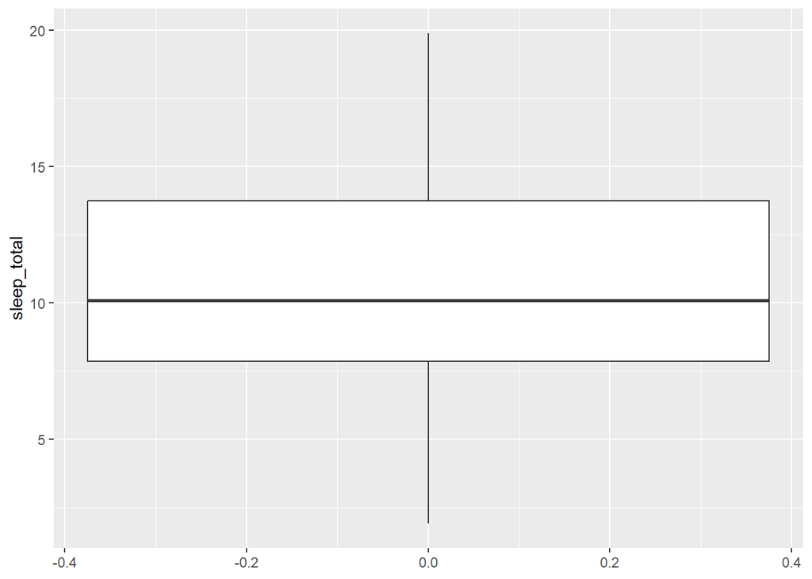

```r
# Box plot with quantile
ggplot(msleep, aes(y=sleep_total)) +
  geom_boxplot()
```

```r
# quantile and break
quantile(msleep$sleep_total, probs = c(0, 0.2, 0.4, 0.6, 0.8, 1))
```

```
##    0%   20%   40%   60%   80%  100%
##  1.90  6.24  9.48 11.14 14.40 19.90
```

```r
quantile(msleep$sleep_total, probs = seq(0, 1, 0.2))  #  the same result with above
```

```
##    0%   20%   40%   60%   80%  100%
##  1.90  6.24  9.48 11.14 14.40 19.90
```

```r
# Inter quantile range and finding the outlier
iqr <- quantile(msleep$sleep_total, 0.75) - quantile(msleep$sleep_total, 0.25)
iqr
```

```
## 75%
## 5.9
```

```r
# Computing the lower and upper boundaries
lower_threshold <- quantile(msleep$bodywt, 0.25) - 1.5 * iqr
upper_threshold <- quantile(msleep$bodywt, 0.75) + 1.5 * iqr

# Finding the outlier

msleep %>%
  filter(bodywt < lower_threshold | bodywt > upper_threshold) %>%
  select(name, vore, sleep_total, bodywt)
```

```
## # A tibble: 20 × 4
##    name                 vore    sleep_total bodywt
##    <chr>                <chr>         <dbl>  <dbl>
##  1 Cow                  herbi           4    600
##  2 Asian elephant       herbi           3.9 2547
##  3 Horse                herbi           2.9  521
##  4 Donkey               herbi           3.1  187
##  5 Giraffe              herbi           1.9  900.
##  6 Pilot whale          carni           2.7  800
##  7 Gray seal            carni           6.2   85
##  8 Human                omni            8     62
##  9 African elephant     herbi           3.3 6654
## 10 Sheep                herbi           3.8   55.5
## 11 Chimpanzee           omni            9.7   52.2
## 12 Tiger                carni          15.8  163.
## 13 Jaguar               carni          10.4  100
## 14 Lion                 carni          13.5  161.
## 15 Caspian seal         carni           3.5   86
## 16 Common porpoise      carni           5.6   53.2
## 17 Giant armadillo      insecti        18.1   60
## 18 Pig                  omni            9.1   86.2
## 19 Brazilian tapir      herbi           4.4  208.
## 20 Bottle-nosed dolphin carni           5.2  173.
```

# Random Numbers and Probability

## Chances

```r
#Random sample
data(mtcars)

mtcars %>% sample_n(1)  #Get random number , not get the same result if run it again
```

```
##              mpg cyl disp  hp drat    wt qsec vs am gear carb
## AMC Javelin 15.2   8  304 150 3.15 3.435 17.3  0  0    3    2
```

```r
#To get the same random sample

set.seed(5)   # R random number generator
mtcars %>%
  sample_n(1)  # sometime it couldn't be worked, can use slice_sample instead
```

```
##               mpg cyl disp  hp drat    wt  qsec vs am gear carb
## Mazda RX4 Wag  21   6  160 110  3.9 2.875 17.02  0  1    4    4
```

```r
#Sample with replacement
mtcars %>%
  sample_n(2, replace=TRUE) # default is FALSE, so need to set up TRUE
```

```
##                   mpg cyl  disp  hp drat    wt  qsec vs am gear carb
## Merc 280C        17.8   6 167.6 123 3.92 3.440 18.90  1  0    4    4
## Pontiac Firebird 19.2   8 400.0 175 3.08 3.845 17.05  0  0    3    2
```

## Discrete Probability Distribution

Discrete distributions describe phenomena where outcomes can be counted in whole numbers.

```r
# Create a die for example
die <- data.frame(
  n = 1:6,
  probability = rep(1/6, 6)  # Equal probability for each outcome
)
die
```

```
##   n probability
## 1 1   0.1666667
## 2 2   0.1666667
## 3 3   0.1666667
## 4 4   0.1666667
## 5 5   0.1666667
## 6 6   0.1666667
```

```r
#mean die
mean(die$n)
```

```
## [1] 3.5
```

```r
#roll the die 10 times
set.seed(5)
roll_10 <-
  die %>%
  sample_n(10, replace = TRUE)

mean(roll_10$n)
```

```
## [1] 2.8
```

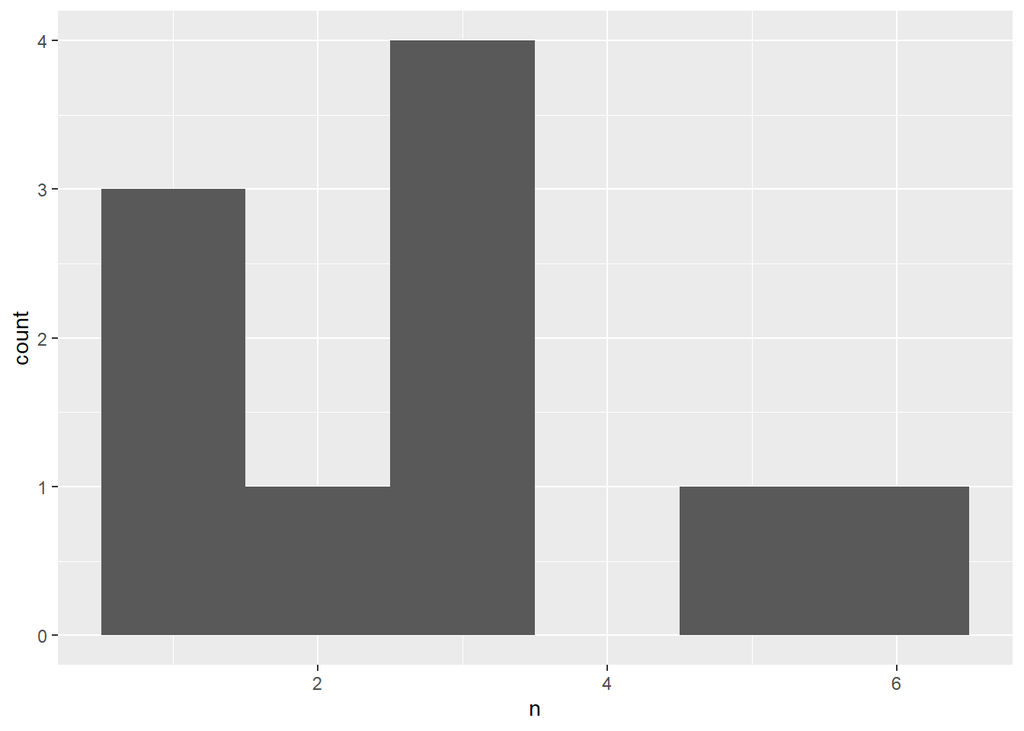

```r
ggplot(roll_10, aes(n)) +
  geom_histogram(bins = 6)
```

```r
#roll the die 100 times
set.seed(5)
roll_100 <-
  die %>%
  sample_n(100, replace = TRUE) # if the rolling times is increased (e.g 10 to 100) , the distribution of rolls look a bit more even, and the random mean is closer to original mean. look at below

mean(roll_100$n)
```

```
## [1] 3.43
```

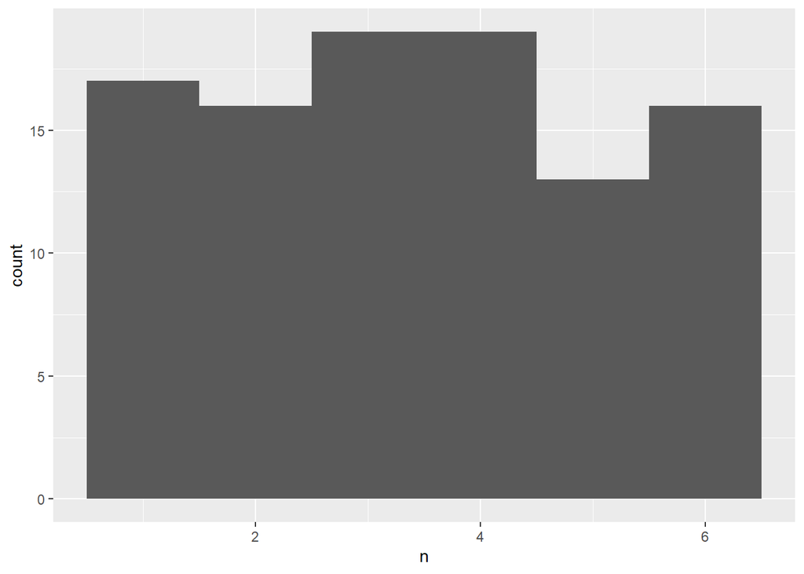

```r
ggplot(roll_100, aes(n)) +
  geom_histogram(bins = 6)
```

## Continuous Probability Distribution

Continuous distributions are used for data that can take any value within a range, including decimals.

```r
# Create a dataset for bus wait
set.seed(123)
bus_wait <- data.frame(wait = runif(200, min = 0, max = 12)) #

# Uniform distribution in R

punif(7, min = 0, max = 12)  # P(wait time ≤ 7)
```

```
## [1] 0.5833333
```

```r
punif(7, min = 0, max = 12, lower.tail = FALSE)  # P(wait time ≥ 7)
```

```
## [1] 0.4166667
```

```r
punif(7, min = 0, max = 12) - punif(4, min = 0, max = 12) # P(4 ≤ wait time ≤ 7)
```

```
## [1] 0.25
```

## Binomial Distribution

*BINOMIAL PROBABILITY FUNCTION*

$$f(x) \;=\; \binom{n}{x}\, p^{\,x}\,(1-p)^{\,n-x}$$

x = the number of successes, p = the probability of a success on one trial, n = the number of trials, f(x) = the probability of x successes in n trials

```r
#rbinom(# of trials, # of coins, # probability of heads)
#1 = head, 0 = tails
rbinom(1, 1, 0.5)  # One flip → returns 0 or 1
```

```
## [1] 0
```

```r
rbinom(8, 1, 0.5)  # Eight flips
```

```
## [1] 1 1 1 0 1 0 0 0
```

```r
rbinom(1, 8, 0.5)  # One flips 8 coils , give the one number, is the total number of head or successes.
```

```
## [1] 3
```

```r
rbinom(10, 3, 0.5)  # Many flips and many times
```

```
##  [1] 1 1 1 2 0 2 1 1 2 3
```

```r
# binomial distribution
#Parameters:
#size = number of trials per observation
#prob = probability of success
#n = number of observations (simulations - trials)

dbinom(7, size = 10, prob = 0.5) #P(HEADS=7)
```

```
## [1] 0.1171875
```

```r
pbinom(7, size = 10, prob = 0.5) #P(Heads ≤ 7)
```

```
## [1] 0.9453125
```

```r
pbinom(7, size = 10, prob = 0.5, lower.tail = FALSE) #P(Heads ≥ 7)
```

```
## [1] 0.0546875
```

```r
1-pbinom(7, size = 10, prob = 0.5) #P(Heads ≥ 7) , same result
```

```
## [1] 0.0546875
```

# More distribution and Central Limit Theorem

## Normal Distribion

```r
# Installing the national health and nutrition examination survey dataset
#install.packages("NHANES")
library(NHANES)

# View available variables
names(NHANES)
```

```
##  [1] "ID"               "SurveyYr"         "Gender"           "Age"
##  [5] "AgeDecade"        "AgeMonths"        "Race1"            "Race3"
##  [9] "Education"        "MaritalStatus"    "HHIncome"         "HHIncomeMid"
## [13] "Poverty"          "HomeRooms"        "HomeOwn"          "Work"
## [17] "Weight"           "Length"           "HeadCirc"         "Height"
## [21] "BMI"              "BMICatUnder20yrs" "BMI_WHO"          "Pulse"
## [25] "BPSysAve"         "BPDiaAve"         "BPSys1"           "BPDia1"
## [29] "BPSys2"           "BPDia2"           "BPSys3"           "BPDia3"
## [33] "Testosterone"     "DirectChol"       "TotChol"          "UrineVol1"
## [37] "UrineFlow1"       "UrineVol2"        "UrineFlow2"       "Diabetes"
## [41] "DiabetesAge"      "HealthGen"        "DaysPhysHlthBad"  "DaysMentHlthBad"
## [45] "LittleInterest"   "Depressed"        "nPregnancies"     "nBabies"
## [49] "Age1stBaby"       "SleepHrsNight"    "SleepTrouble"     "PhysActive"
## [53] "PhysActiveDays"   "TVHrsDay"         "CompHrsDay"       "TVHrsDayChild"
## [57] "CompHrsDayChild"  "Alcohol12PlusYr"  "AlcoholDay"       "AlcoholYear"
## [61] "SmokeNow"         "Smoke100"         "Smoke100n"        "SmokeAge"
## [65] "Marijuana"        "AgeFirstMarij"    "RegularMarij"     "AgeRegMarij"
## [69] "HardDrugs"        "SexEver"          "SexAge"           "SexNumPartnLife"
## [73] "SexNumPartYear"   "SameSex"          "SexOrientation"   "PregnantNow"
```

```r
# Filter for women and height
women_height <- subset(NHANES, Gender == "female", select = c(Age, Height))
head(women_height)
```

```
## # A tibble: 6 × 2
##     Age Height
##   <int>  <dbl>
## 1    49   168.
## 2    45   167.
## 3    45   167.
## 4    45   167.
## 5    10   142.
## 6    58   148.
```

```r
#What percent of women are shorter than 154 cm?
pnorm(154, mean = 161, sd = 7) # 16% of women are shorter than 154 cm of height
```

```
## [1] 0.1586553
```

```r
#What percent of women are taller than 154 cm?
pnorm(154, mean = 161, sd = 7, lower.tail = FALSE) # 84%
```

```
## [1] 0.8413447
```

```r
#What percent of women are 154–157 cm?
pnorm(157, mean = 161, sd = 7) - pnorm(154, mean = 161, sd = 7)
```

```
## [1] 0.1251993
```

```r
#What height are 90% of women shorter than?
qnorm(0.9, mean = 161, sd = 7)
```

```
## [1] 169.9709
```

```r
#What height are 90% of women taller than?
qnorm(0.9, mean = 161, sd = 7, lower.tail = FALSE)
```

```
## [1] 152.0291
```

```r
# Generate 10 random heights
rnorm(10, mean = 161, sd = 7)
```

```
##  [1] 156.9726 165.2558 149.6748 160.6111 164.6359 163.1081 161.7397 156.5151
##  [9] 155.0521 153.8311
```

## Central Limit Theorem

The central limit theorem, or CLT, is an idea in statistics that says that if we take a bunch of random samples from any population and look at the averages of those samples, those averages will start to form a normal, bell-shaped curve even if the original population doesn’t look normal at all.

The central limit theorem states that, with a sufficiently large sample size, the sampling distribution of the mean will be normally distributed, regardless of the population’s distribution.

The CLT helps us understand how those sample results behave and it tells us that if we take enough samples, their averages will start to look like a normal distribution, even if the original data is anything but.

```r
# Creat a die vector

die <- c(1,2,3,4,5,6)

# Roll the die 5 times

sample_of_5 <- sample(die, 5, replace = TRUE)

mean_sample5 <- sample(die, 5, replace = TRUE) %>% mean()

mean_sample5
```

```
## [1] 3
```

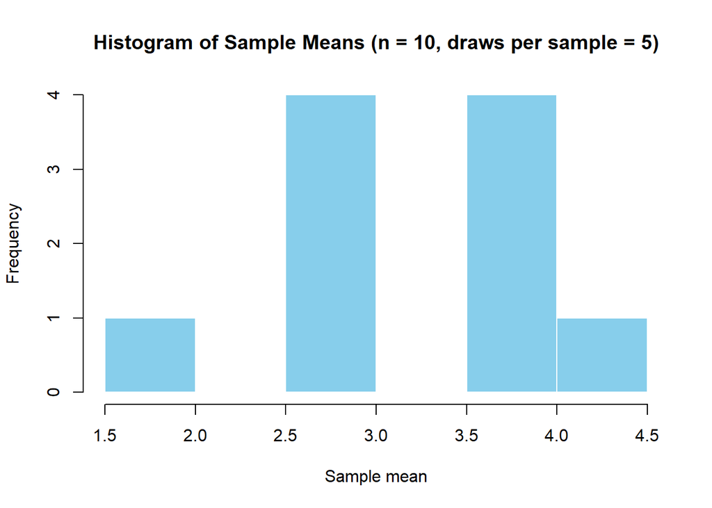

```r
# Rolling the dice 5 times 10 times

sample_means_10 <- replicate(10, sample(die, 5, replace = TRUE) %>% mean())  # return 10 different sample means


hist(sample_means_10,
     main = "Histogram of Sample Means (n = 10, draws per sample = 5)",
     xlab = "Sample mean", col = "skyblue", border = "white")
```

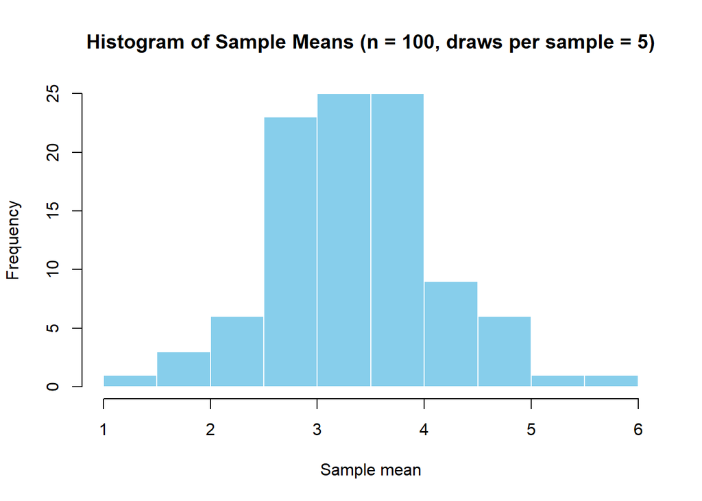

```r
# Rolling the dice 5 times 100 times

sample_means_100 <-replicate(100, sample(die, 5, replace = TRUE) %>%  mean())

hist(sample_means_100,
     main = "Histogram of Sample Means (n = 100, draws per sample = 5)",
     xlab = "Sample mean", col = "skyblue", border = "white")
```

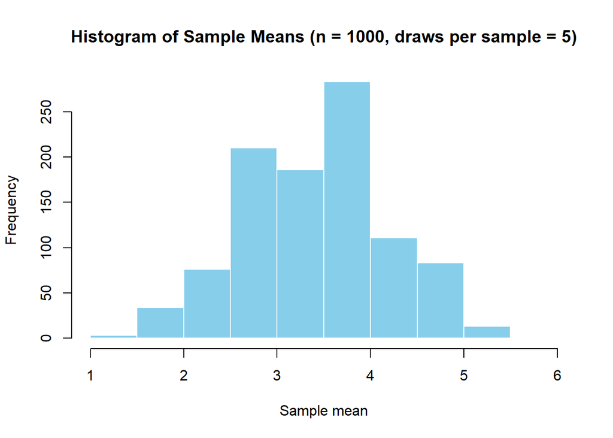

```r
# Rolling the dice 5 times 1000 times

sample_means_100 <-replicate(1000, sample(die, 5, replace = TRUE) %>%  mean())

hist(sample_means_100,
     main = "Histogram of Sample Means (n = 1000, draws per sample = 5)",
     xlab = "Sample mean", col = "skyblue", border = "white")
```

## Poisson Distribution

The Poisson distribution is a discrete probability distribution that expresses the probability of a given number of events occurring in a fixed interval of time or space. It assumes these events happen with a known average rate and independently of the time since the last event. To understand the Poisson distribution, it’s first helpful to know the difference between discrete and continuous distributions.

A key characteristic of the Poisson distribution is its ability to model events in a fixed interval. This interval can be time (e.g., number of customers arriving per hour) or space (e.g., number of defects per square meter of fabric). The model assumes:

1. Events occur independently.
2. The average rate of occurrence (λ) remains constant over the interval.
3. Two events cannot occur at exactly the same instant.

$$f(x) \;=\; \frac{e^{-\lambda}\lambda^{x}}{x!},
\qquad x = 0,1,2,\ldots$$

```r
# If the average number of adoption per week is 8, what is P(# adoption in a week = 5 )
dpois(5, lambda = 8)
```

```
## [1] 0.09160366
```

```r
# If the average number of adoption per week is 8, what is P(# adoption in a week < 5 )
ppois(5, lambda = 8)
```

```
## [1] 0.1912361
```

```r
# If the average number of adoption per week is 8, what is P(# adoption in a week > 5 )
ppois(5, lambda = 8, lower.tail = FALSE)
```

```
## [1] 0.8087639
```

```r
# If the average number of adoption per week is 10, what is P(# adoption in a week > 5 )
ppois(5, lambda = 10, lower.tail = FALSE)
```

```
## [1] 0.932914
```

```r
# Sampling from the poisson distribution
rpois(10, lambda = 8)
```

```
##  [1]  8  3  7 12  6  4  7  6  8  7
```

## Exponential Distribution

The exponential distribution is a continuous probability distribution that models the time between events in a process where events occur continuously and independently at a constant average rate. It’s particularly useful for analyzing situations involving waiting times, lifetimes, and intervals between events.

Imagine you’re working at a busy customer service center. The time between incoming customer calls often follows an exponential distribution. Similarly, in manufacturing, the time until a machine fails or needs maintenance frequently exhibits exponential behavior.

Example Calculation Suppose:

Average 3 calls per minute → λ=3 What’s the probability that the next call comes after 30 seconds (0.5 min)?

```r
lambda <- 3       # calls per minute
t <- 0.5          # 30 seconds in minutes
prob_after_30sec <- exp(-lambda * t)
prob_after_30sec
```

```
## [1] 0.2231302
```

# Correlation and Experiment Designs

## Correlation

Correlation measures the strength and direction of a linear relationship between two quantitative variables. It helps you understand how changes in one variable are associated with changes in another.

A positive correlation means that as one variable increases, the other tends to increase as well. A negative correlation means that as one variable increases, the other tends to decrease

```r
# Look at first few rows
head(mtcars)
```

```
##                    mpg cyl disp  hp drat    wt  qsec vs am gear carb
## Mazda RX4         21.0   6  160 110 3.90 2.620 16.46  0  1    4    4
## Mazda RX4 Wag     21.0   6  160 110 3.90 2.875 17.02  0  1    4    4
## Datsun 710        22.8   4  108  93 3.85 2.320 18.61  1  1    4    1
## Hornet 4 Drive    21.4   6  258 110 3.08 3.215 19.44  1  0    3    1
## Hornet Sportabout 18.7   8  360 175 3.15 3.440 17.02  0  0    3    2
## Valiant           18.1   6  225 105 2.76 3.460 20.22  1  0    3    1
```

```r
# Compute correlation between mpg (miles per gallon) and hp (horsepower)
cor(mtcars$mpg, mtcars$hp)
```

```
## [1] -0.7761684
```

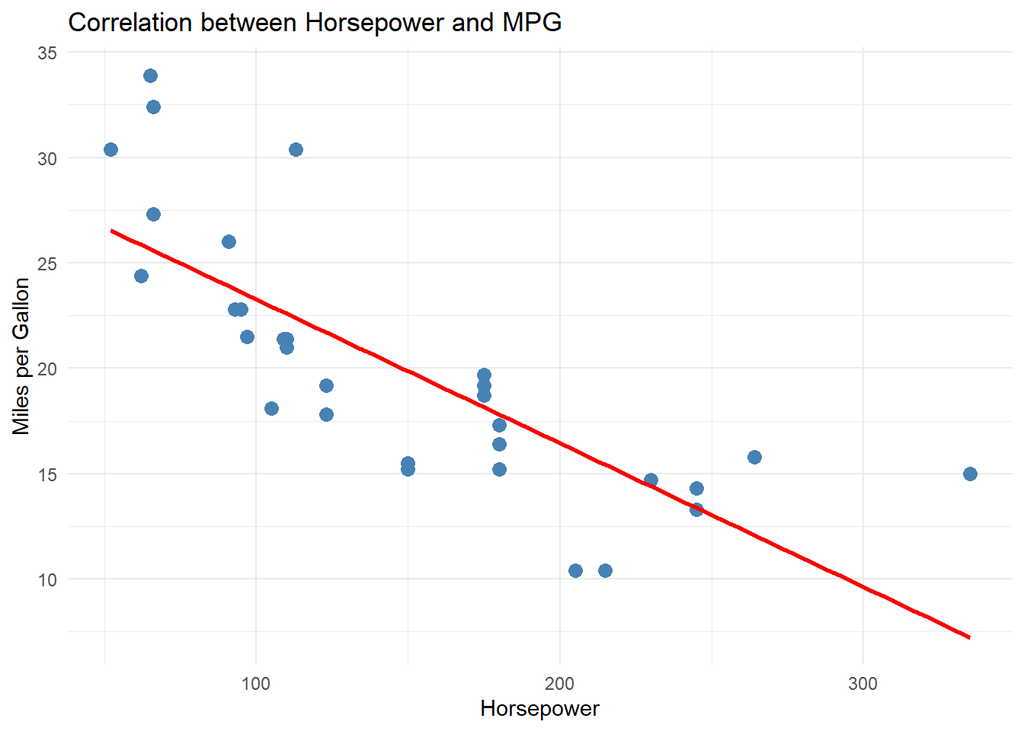

```r
# Visualize with ggplot2

ggplot(mtcars, aes(x = hp, y = mpg)) +
  geom_point(color = "steelblue", size = 3) +
  geom_smooth(method = "lm", se = FALSE, color = "red") +
  labs(title = "Correlation between Horsepower and MPG",
       x = "Horsepower", y = "Miles per Gallon") +
  theme_minimal()
```

## Correlation caveats

Log transformation

When to Apply Log Transformation:

- Right-Skewed Data: If your variable has a long tail (e.g., income, body weight, population), log helps normalize the distribution. Multiplicative or Exponential Relationships: If the effect grows proportionally (e.g., growth rates, biological scaling), log can linearize the pattern.
- Variance Increases with Magnitude (Heteroscedasticity): When residuals spread out as values grow, log stabilizes variance.
- Interpretation in Percent Change: If you want to interpret coefficients as percentage changes rather than absolute changes.
- Values Span Several Orders of Magnitude: Log compresses large ranges, making patterns clearer and reducing outlier influence

```r
cor(msleep$bodywt, msleep$awake)
```

```
## [1] 0.3119801
```

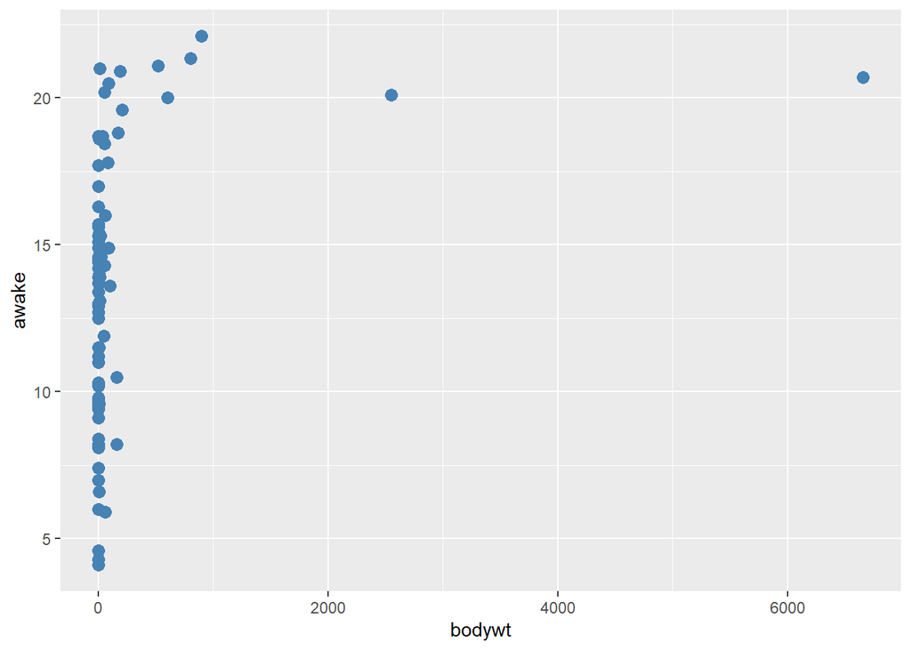

```r
ggplot(msleep, aes(bodywt, awake)) +
   geom_point(color = "steelblue", size = 3) # the distribution of body weight is highly skewed, a weak linear relationship
```

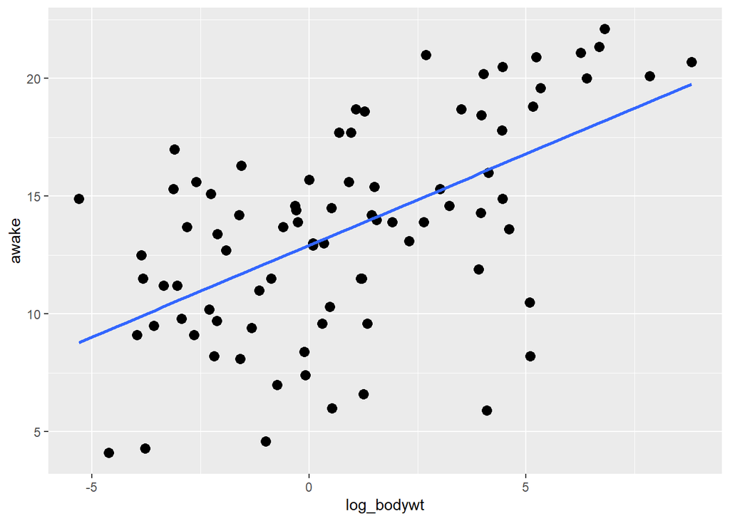

```r
# When data is highly skewed, we can apply a log transformation

msleep %>%
  mutate(log_bodywt = log(bodywt)) %>%
  ggplot(aes(log_bodywt, awake)) +
   geom_point(color = "black", size = 3) +
  geom_smooth(method = "lm", se=FALSE)
```

```r
msleep <- msleep %>%
  mutate(log_bodywt = log(bodywt))

  cor(msleep$log_bodywt,msleep$awake)
```

```
## [1] 0.5687943
```

## Cofounding

A phenomenon called confounding can lead to spurious correlations. Let’s say we want to know if drinking coffee causes lung cancer. Looking at the data, we find that coffee drinking and lung cancer are correlated, which may lead us to think that drinking more coffee will give you lung cancer.